# Data Science in Practice Problem Set3

Group Members: Jingwei Chen, Ju-Hsuan Hsieh, Junze Li, Yuening Zhan, Yunbei Wang

## Outlines

- 0.Data extraction
- 1.Explore the basic information of the network
- 2.Degree and centrality distribution
- 3.Detect connected components
- 4.Graph visualization
- 5.Detect important nodes based on Page Rank
- 6.Community detection
- 7.Practice: find the most efficient patents

```python
import numpy as np
import pandas as pd
import matplotlib.pyplot as plt
import networkx as nx
import itertools
import warnings
warnings.filterwarnings("ignore")
```

### 0. Data extraction

We try to extract the data in **Google Patents Datasets** based on Google BigQuery platform. We should extract all patents from 2016 from that have a patent classiﬁcation (cpc) starting with G06Q30/06. Then, extract all the patents from 2016-2020 that cite these patents, and build a directed network of patent citations.

In the patents-public-data/patents/pulications table, the following attributes are related:

- **publication_number**: Patent publication number (DOCDB compatible), eg: 'US-7650331-B1'
- **publication_date**: The publication date.
- **cpc.code**: The Cooperative Patent Classification (CPC) codes.
- **citation.publication_number**: The citations of this publication.

The pseudo-code to extract the data:

SELECT pub.publication_number, cite.publication_number cite_publication_number

FROM `patents-public-data.patents.publications` pub, UNNEST(cpc) classification, UNNEST(citation) cite

WHERE pub.publication_date > 20160000 and classification.code like 'G06Q30/06%' and (SELECT publication_date FROM `patents-public-data.patents.publications` WHERE publication_number = cite.publication_number) > 20160000

```python
# Load the data
network_data = nx.read_edgelist('network.txt')
```

### 1. Explore the basic information of the network

```python
print('The number of nodes is: {}.'.format(network_data.number_of_nodes()))
print('The number of edges is: {}.'.format(network_data.number_of_edges()))
print('The average degree is: {:.2f}.'.format(2*network_data.number_of_edges()/network_data.number_of_nodes()))
```

```
The number of nodes is: 4039.
The number of edges is: 88234.
The average degree is: 43.69.
```

We can also implement the command in NetworkX to observe the graph directly.

```python
print(nx.info(network_data))
```

```
Name:
Type: Graph
Number of nodes: 4039
Number of edges: 88234
Average degree:  43.6910
```

### 2. Degree and centrality distribution

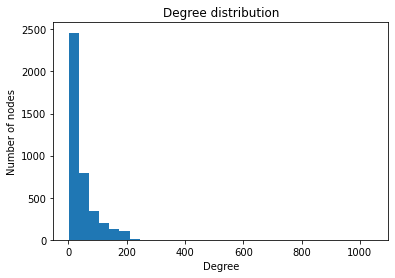

```python
degree_list = dict(network_data.degree()).values()
plt.hist(degree_list, 30)
plt.xlabel('Degree')
plt.ylabel('Number of nodes')
plt.title('Degree distribution')
plt.show()
```

```python
# Compute the degree centrality
centrality = nx.degree_centrality(network_data)
# Rank the nodes based on degree centrality
sorted(centrality.items(), key = lambda x: x[1], reverse = True)[:10]
```

```
[('107', 0.258791480931154),
 ('1684', 0.1961367013372957),
 ('1912', 0.18697374938088163),
 ('3437', 0.13546310054482416),
 ('0', 0.08593363051015354),
 ('2543', 0.07280832095096582),
 ('2347', 0.07206537890044576),
 ('1888', 0.0629024269440317),
 ('1800', 0.06067360079247152),
 ('1663', 0.058197127290737984)]
```

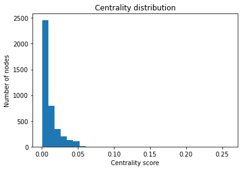

```python
plt.hist(centrality.values(), 30)
plt.xlabel('Centrality score')
plt.ylabel('Number of nodes')
plt.title('Centrality distribution')
plt.show()
```

We can notice that there are very few nodes with high centrality scores and we want to find these central nodes.

### 3. Detect connected components

```python
print('The number of connected components is {}.'.format(nx.number_connected_components(network_data)))
```

```
The number of connected components is 1.
```

```python
print('The number of nodes in this connected component is {}.'.format([len(conn) for conn in nx.connected_components(network_data)][0]))
```

```
The number of nodes in this connected component is 4039.
```

### 4. Graph visualization

```python
node_bc = nx.betweenness_centrality(network_data, normalized = True, endpoints = True)
# Determine the node color based on node degree
node_color = [20000 * network_data.degree(node) for node in network_data]
# Determine the node size based on betweenness centrality
node_size =  [10000 * value for value in node_bc.values()]
```

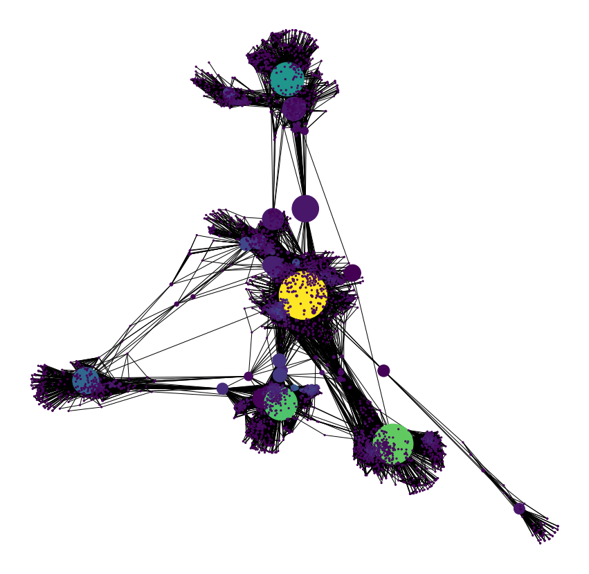

```python
plt.figure(figsize=(15,15))
nx.draw_networkx(network_data, pos = nx.spring_layout(network_data), with_labels=False, node_color = node_color, node_size = node_size)
plt.axis('off')
plt.show()
```

### 5. Detect important nodes based on Page Rank

Based on the connection relationship between different nodes, we want to detect the most important nodes. We implement Page Rank algorithm to give every node a Page Rank score which can be used to rank the nodes. The most important (central) nodes have higher ranks and more random walks arrive them.

**Original Page Rank**

```python
# Compute Page Rank score
page_rank_score = nx.pagerank(network_data, alpha = 0.9)
page_rank_score_sorted = sorted(page_rank_score.items(), key = lambda x: x[1], reverse = True)
```

```python
page_rank_score_sorted[:10]
```

```
[('3437', 0.0075486383122593936),
 ('107', 0.006674335170515213),
 ('1684', 0.0062127563509936385),
 ('0', 0.006079606981157082),
 ('1912', 0.0036943298880784793),
 ('348', 0.002256043753096586),
 ('686', 0.0022167595439287363),
 ('3980', 0.0021526673819292747),
 ('414', 0.0017198586439191863),
 ('483', 0.0013718785902134194)]
```

We can notice that node '3437' has the highest Page Rank score which indicates it is the most important node.

**Biased Page Rank**

If we are interested in some nodes, for example some patents that are related to our new technologies, we could introduce bias into our Page Rank algorithm. Here we assume that the first five nodes in the above result are the nodes we interested in, and we can compare the difference.

```python
# Give the set of interested nodes
personal_nodes_set = ['3437','107', '1684','0','1912']
# Build the dictionary to save the weight of each node
personal_dict = {}
for n in network_data.nodes():
    personal_dict[n] = 0
for n in personal_nodes_set:
    personal_dict[n] = 0.7

# Compute the Page Rank score
page_rank_score_personal = nx.pagerank(network_data, alpha=0.9, personalization = personal_dict)
page_rank_score_personal_sorted = sorted(page_rank_score_personal.items(), key = lambda x: x[1], reverse = True)
```

```python
page_rank_score_personal_sorted[:10]
```

```
[('0', 0.03172857481314998),
 ('3437', 0.02950693516888283),
 ('1684', 0.025696509436925415),
 ('107', 0.024793490707420887),
 ('1912', 0.023466019660163012),
 ('56', 0.0016786009353687613),
 ('25', 0.00162957790130589),
 ('67', 0.0016187175168381127),
 ('322', 0.0016181044051259538),
 ('271', 0.0015664053028896724)]
```

We can notice that our interested nodes have higher scores than before, and the other high ranked nodes are also different, which are the nodes have close relationships with our interested nodes. So in this way, we can detect the nodes that we are interested in. This algorithm can also be used in fraud detection, recommendation systems etc.

### 6. Community detection

We find communities in graph using Clauset-Newman-Moore greedy modularity maximization, which begins with each node in its own community and joins the pair of communities that most increases modularity until no such pair exists.

```python
# Implement greedy modularity maximization algorithm to detect communities
communities_detected = nx.community.greedy_modularity_communities(network_data)
```

```python
print('There are {} communities we detected.'.format(len(communities_detected)))
```

```
There are 13 communities we detected.
```

```python
# Assign the community number to each node
for n in network_data.nodes:
    for community_num, node_list in enumerate(communities_detected):
        if n in node_list:
            network_data.nodes[n]['community'] = community_num
```

**Visualization**

```python
# Determine the color for each node
base_color = plt.cm.get_cmap('plasma', len(communities_detected))
color_list = base_color(np.linspace(0, 1, len(communities_detected)))
node_color_cluster = [color_list[network_data.nodes[n]['community']] for n in network_data]
```

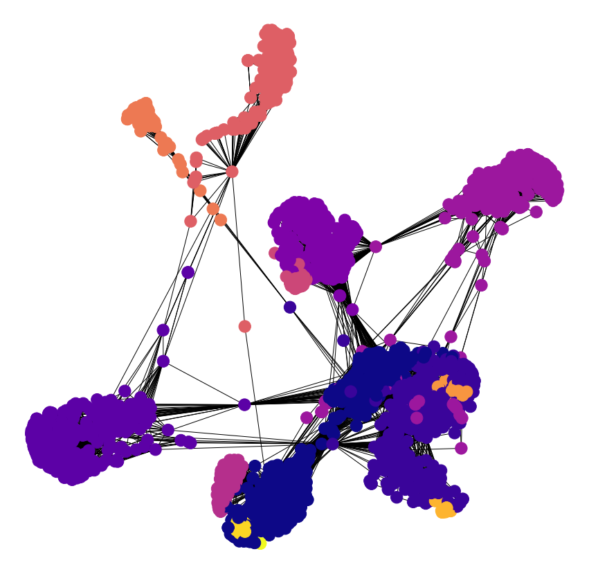

```python
plt.figure(figsize = (15,15))
nx.draw_networkx(network_data, pos = nx.spring_layout(network_data), with_labels = False, node_color = node_color_cluster)
plt.axis('off')
plt.show()
```

### 7. Practice: find the most efficient patents

Since there are plenty of patents, we should find a small group of patents that are efficient and we can focus on. In this way, we can save a lot of money, time and human resource. Here we use three metrics to evaluate the efficiency.

**A. Cost**

which is defined by the sum of the square of the number of neighbours of each node in the node list

```python
def compute_cost(node_list):
    cost_cnt = 0
    for node in node_list:
        # Sum the square of number of neighbors
        cost = (len(list(network_data.neighbors(node))))**2
        cost_cnt = cost_cnt + cost
    return cost_cnt
```

**B. Coverage**

which is defined by the ratio between the number of all neighbors of the node list and the number of all nodes in the graph.

```python
def compute_coverage(node_list):
    all_neighbor_nodes = []
    # Find all the neighbors
    for node in node_list:
        all_neighbor_nodes.extend([n for n in network_data.neighbors(node)])
    # Compute the ratio
    return len(set(all_neighbor_nodes))/len(network_data.nodes())
```

**C. Closeness centrality**

Closeness centrality of a node u is the reciprocal of the sum of the shortest path distances from u to all n-1 other nodes. Since the sum of distances depends on the number of nodes in the graph, closeness is normalized by the sum of minimum possible distances n-1.

The higher value indicates higher centrality.

```python
# Compute closeness centrality for nodes
cc_node_list = nx.closeness_centrality(network_data)
```

```python
# Rank the closeness centrality score
top_central = sorted(cc_node_list.items(), key = lambda x: x[1], reverse = True)
# Find the top 10 central nodes
node_list_initial = [x[0] for x in top_central][:10]

print('The list of these most central nodes is {}.'.format(node_list_initial))
print('The cost of this list is {}.'.format(compute_cost(node_list_initial)))
print('The coverage of this list is {:.2f}.'.format(compute_coverage(node_list_initial)))
```

```
The list of these most central nodes is ['107', '58', '428', '563', '1684', '171', '348', '483', '414', '376'].
The cost of this list is 1890195.
The coverage of this list is 0.53.
```

If we want to focus some nodes of the most central nodes, we can set the thresholds for cost and coverage respectively and find the appropriate nodes.

```python
# Determine the thresholds and the most number of nodes
cost_thres = 1750000
coverage_thres = 0.4
most_num_nodes = 3
cnt = 0
for i in range(0, most_num_nodes + 1):
    # Iterate all the possible subset of different size
    for subset in itertools.combinations(node_list_initial, i):
        # Compare to the threshold
        if compute_cost(subset) <= cost_thres and compute_coverage(subset) >= coverage_thres:
            cnt += 1
            print('***************The possible subset {}********************************'.format(cnt))
            print('The nodes in this subset are {}.'.format(subset))
            print('The cost of this subset is {}.'.format(compute_cost(subset)))
            print('The coverage of this subset is {:.2f}.'.format(compute_coverage(subset)))
```

```
***************The possible subset 1********************************
The nodes in this subset are ('107', '1684').
The cost of this subset is 1719289.
The coverage of this subset is 0.45.
***************The possible subset 2********************************
The nodes in this subset are ('107', '58', '1684').
The cost of this subset is 1719433.
The coverage of this subset is 0.45.
***************The possible subset 3********************************
The nodes in this subset are ('107', '428', '1684').
The cost of this subset is 1732514.
The coverage of this subset is 0.47.
***************The possible subset 4********************************
The nodes in this subset are ('107', '563', '1684').
The cost of this subset is 1727570.
The coverage of this subset is 0.47.
***************The possible subset 5********************************
The nodes in this subset are ('107', '1684', '171').
The cost of this subset is 1719773.
The coverage of this subset is 0.45.
***************The possible subset 6********************************
The nodes in this subset are ('107', '1684', '414').
The cost of this subset is 1744570.
The coverage of this subset is 0.49.
***************The possible subset 7********************************
The nodes in this subset are ('107', '1684', '376').
The cost of this subset is 1736978.
The coverage of this subset is 0.48.
```

Therefore, we could choose the thresholds for cost and coverage and the max number of patents based on our budget and human resource. Then the lawyers will subsequently use this information in order to study their patent portfolios and make the best of our resourses!